# Hierarchical Clustering

```r
library(tidyverse)
library(cluster)
library(factoextra)
library(dendextend)
library(corrplot)
```

```r
edu_data <- read_csv("data/school_data.csv")
```

```r
head(edu_data)
```

| X1 | home_school | state_school | urban_pop | private_school |
| --- | --- | --- | --- | --- |
| Alabama | 1320 | 23600 | 5800 | 2120 |
| Alaska | 1000 | 26300 | 4800 | 4450 |
| Arizona | 810 | 29400 | 8000 | 3100 |
| Arkansas | 880 | 19000 | 5000 | 1950 |
| California | 900 | 27600 | 9100 | 4060 |
| Colorado | 790 | 20400 | 7800 | 3870 |

```r
# check the data. For clustering, we want no text, but want to be able to view the states still. We can get round this, by moving the column (X1) which has our text, into the rownames instead.
edu_data <- edu_data %>%
  column_to_rownames("X1")
head(edu_data)
```

|  | home_school | state_school | urban_pop | private_school |
| --- | --- | --- | --- | --- |
| Alabama | 1320 | 23600 | 5800 | 2120 |
| Alaska | 1000 | 26300 | 4800 | 4450 |
| Arizona | 810 | 29400 | 8000 | 3100 |
| Arkansas | 880 | 19000 | 5000 | 1950 |
| California | 900 | 27600 | 9100 | 4060 |
| Colorado | 790 | 20400 | 7800 | 3870 |

```r
any(is.na(edu_data))
```

```
[1] FALSE
```

```r
edu_data_scale <- edu_data %>%
              mutate_if(is.numeric, scale)

edu_data_scale <- edu_data %>%   # dose the same but is more up todate
              mutate(across(where(is.numeric), scale))

edu_data_scale
```

|  | home_school | state_school | urban_pop | private_school |
| --- | --- | --- | --- | --- |
| Alabama | 1.24256408 | 0.78283935 | -0.52090661 | -0.003416473 |
| Alaska | 0.50786248 | 1.10682252 | -1.21176419 | 2.484202941 |
| Arizona | 0.07163341 | 1.47880321 | 0.99898006 | 1.042878388 |
| Arkansas | 0.23234938 | 0.23086801 | -1.07359268 | -0.184916602 |
| California | 0.27826823 | 1.26281442 | 1.75892340 | 2.067820292 |
| Colorado | 0.02571456 | 0.39885929 | 0.86080854 | 1.864967207 |
| Connecticut | -1.03041900 | -0.72908214 | 0.79172279 | -1.081740768 |
| Delaware | -0.43347395 | 0.80683810 | 0.44629400 | -0.579946294 |
| Florida | 1.74767144 | 1.97077766 | 0.99898006 | 1.138966691 |
| Georgia | 2.20685994 | 0.48285493 | -0.38273510 | 0.487701523 |

[output cut: 40 more lines]

```r
edu_data_scale %>%
  pivot_longer(cols = everything(),
               names_to = "type",
               values_to = "value") %>% #convert data to long format
  group_by(type) %>%
  summarise(mean = round(mean(value)),
            sd = sd(value))
```

| type | mean | sd |
| --- | --- | --- |
| home_school | 0 | 1 |
| private_school | 0 | 1 |
| state_school | 0 | 1 |
| urban_pop | 0 | 1 |

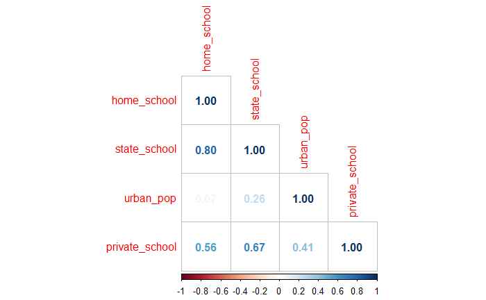

```r
# create a correlation plot
corrplot(cor(edu_data_scale), method = "number", type = "lower")
```

```r
diss_matrix
```

```
                  Alabama     Alaska    Arizona   Arkansas California   Colorado Connecticut   Delaware    Florida
Alaska         0.73470160
Arizona        1.17093068 0.43622908
Arkansas       1.01021470 0.27551310 0.16071598
California     0.96429585 0.22959425 0.20663483 0.04591885
Colorado       1.21684953 0.48214793 0.04591885 0.20663483 0.25255368
Connecticut    2.27298308 1.53828148 1.10205240 1.26276838 1.30868723 1.05613355
Delaware       1.67603803 0.94133643 0.50510735 0.66582333 0.71174218 0.45918850  0.59694505
Florida        0.50510735 1.23980895 1.67603803 1.51532205 1.46940320 1.72195688  2.77809043 2.18114538
Georgia        0.96429585 1.69899745 2.13522653 1.97451055 1.92859170 2.18114538  3.23727893 2.64033388 0.45918850
Hawaii         1.81379458 1.07909298 0.64286390 0.80357988 0.84949873 0.59694505  0.45918850 0.13775655 2.31890193
Idaho          2.43369906 1.69899745 1.26276838 1.42348435 1.46940320 1.21684953  0.16071598 0.75766103 2.93880641
Illinois       0.64286390 0.09183770 0.52806678 0.36735080 0.32143195 0.57398563  1.63011918 1.03317413 1.14797125
Indiana        1.37756550 0.64286390 0.20663483 0.36735080 0.41326965 0.16071598  0.89541758 0.29847253 1.88267285
Iowa           2.52553676 1.79083515 1.35460608 1.51532205 1.56124090 1.30868723  0.25255368 0.84949873 3.03064411
Kansas         1.65307860 0.91837700 0.48214793 0.64286390 0.68878275 0.43622908  0.61990448 0.02295943 2.15818596
Kentucky       0.80357988 0.06887828 0.36735080 0.20663483 0.16071598 0.41326965  1.46940320 0.87245815 1.30868723
Louisiana      0.50510735 1.23980895 1.67603803 1.51532205 1.46940320 1.72195688  2.77809043 2.18114538 0.00000000
Maine          2.54849618 1.81379458 1.37756550 1.53828148 1.58420033 1.33164665  0.27551310 0.87245815 3.05360353
Maryland       0.43622908 0.29847253 0.73470160 0.57398563 0.52806678 0.78062045  1.83675400 1.23980895 0.94133643
Massachusetts  2.02042940 1.28572780 0.84949873 1.01021470 1.05613355 0.80357988  0.25255368 0.34439138 2.52553676
                  Georgia     Hawaii      Idaho   Illinois    Indiana       Iowa     Kansas   Kentucky  Louisiana
Alaska
Arizona
Arkansas
California
Colorado
Connecticut
Delaware
Florida
Georgia
Hawaii         2.77809043
Idaho          3.39799491 0.61990448
Illinois       1.60715975 1.17093068 1.79083515
Indiana        2.34186136 0.43622908 1.05613355 0.73470160
Iowa           3.48983261 0.71174218 0.09183770 1.88267285 1.14797125
Kansas         2.61737446 0.16071598 0.78062045 1.01021470 0.27551310 0.87245815
Kentucky       1.76787573 1.01021470 1.63011918 0.16071598 0.57398563 1.72195688 0.84949873
Louisiana      0.45918850 2.31890193 2.93880641 1.14797125 1.88267285 3.03064411 2.15818596 1.30868723
Maine          3.51279203 0.73470160 0.11479713 1.90563228 1.17093068 0.02295943 0.89541758 1.74491630 3.05360353
```

[output cut: 72 more lines]

[output not shown]

```r
# what it's doing in the background
matrix(1:12, 4)
```

```
     [,1] [,2] [,3]
[1,]    1    5    9
[2,]    2    6   10
[3,]    3    7   11
[4,]    4    8   12
```

```r
dist(matrix(1:12, 4),method = "euclidean")
```

```
         1        2        3
2 1.732051
3 3.464102 1.732051
4 5.196152 3.464102 1.732051
```

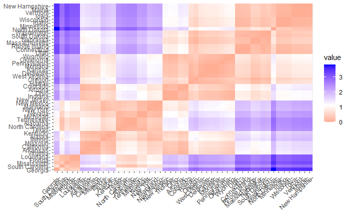

```r
# create a dissimilarity matrix showing distances
fviz_dist(diss_matrix)
```

## Building our dendrogram

```r
clusters <- diss_matrix %>%
                 hclust(method = "complete")
```

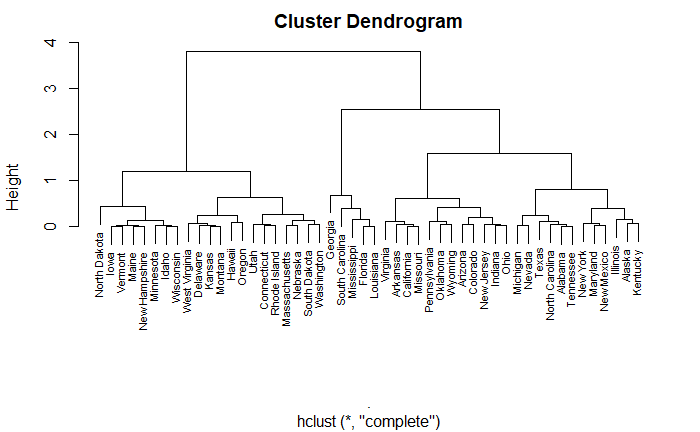

```r
clusters %>%
  plot(cex = 0.7, hang = .1)
```

```r
alt_clusters <- diss_matrix %>%
                    hclust(method = "ward.D2")
```

```r
clustering_dendrogram <- clusters %>%
                                  as.dendrogram() %>%
                                  dendextend::set("labels_cex", 0.5)

clustering_dendrogram
```

```
'dendrogram' with 2 branches and 50 members total, at height 3.811265
```

```r
alt_clustering_dendrogram <- alt_clusters %>%
                              as.dendrogram() %>%
                                 dendextend::set("labels_cex", 0.6)

alt_clustering_dendrogram
```

```
'dendrogram' with 2 branches and 50 members total, at height 8.443229
```

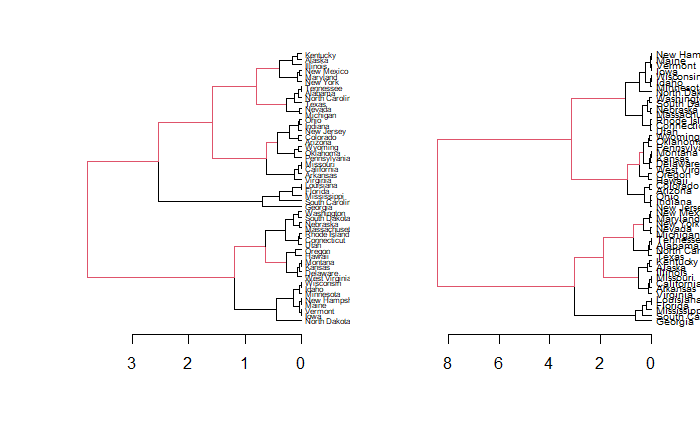

```r
dend_diff(clustering_dendrogram, alt_clustering_dendrogram)
```

The red lines show diffrences

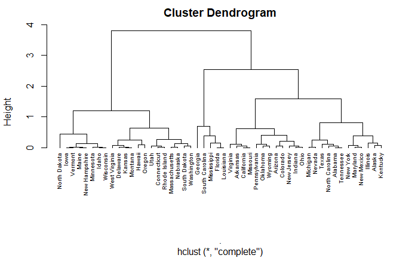

```r
plot(clusters, cex = 0.6, hang = -1)
```

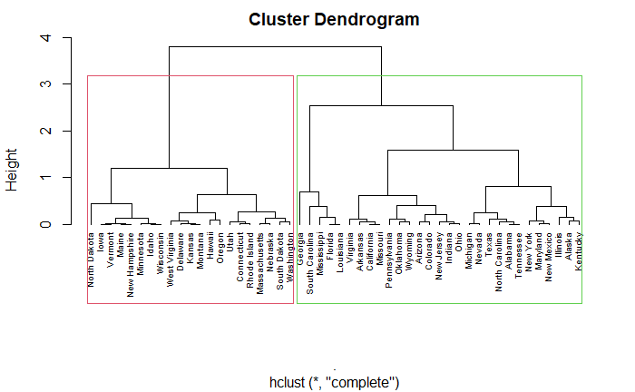

```r
plot(clusters, cex = 0.6, hang = -1)
rect.hclust(clusters, k = 2, border = 2:5)
```

This looks not too bad. Groups don’t seem too big, or too small. In this case, I’d be tempted to stop here and say something along the following lines:

> We investigated education rates (per 100000) across US States using cluster analysis. Based on this analysis, we have defined two cluster groupings. States such as Alaska and Kentucky have similar education rates to one another. States such as Vermont and Maine have similar education rates to one another. These states have different education rates to one another. From our analysis, we could use these clusters to predict future education rate data in these states.

```r
palette()
```

```
[1] "black"   "#DF536B" "#61D04F" "#2297E6" "#28E2E5" "#CD0BBC" "#F5C710" "gray62"
```

```r
edu_clustered_h2 <- edu_data %>%
                          mutate(school_cluster = cutree(clusters, k=2))

head(edu_clustered_h2,20)
```

|  | home_school | state_school | urban_pop | private_school | school_cluster |
| --- | --- | --- | --- | --- | --- |
| Alabama | 1320 | 23600 | 5800 | 2120 | 1 |
| Alaska | 1000 | 26300 | 4800 | 4450 | 1 |
| Arizona | 810 | 29400 | 8000 | 3100 | 1 |
| Arkansas | 880 | 19000 | 5000 | 1950 | 1 |
| California | 900 | 27600 | 9100 | 4060 | 1 |
| Colorado | 790 | 20400 | 7800 | 3870 | 1 |
| Connecticut | 330 | 11000 | 7700 | 1110 | 2 |
| Delaware | 590 | 23800 | 7200 | 1580 | 2 |
| Florida | 1540 | 33500 | 8000 | 3190 | 1 |
| Georgia | 1740 | 21100 | 6000 | 2580 | 1 |

[output cut: 10 more lines]

Task - 20 mins

> Spend some time carrying out cluster analysis for your other variables. What do you find for each variable? How many clusters do you choose, and why? What are your interpretations from your analysis?

> What happens if you include all your data and perform clustering? (i.e. do not subset the data as we did in one of our first steps). For this, you have moved from predicting a specific variable to predicting something you might denoted as “overall education rates”. Do you get different results when the clustering takes into account all your data at once for each state? How would you interpret your results?

### Overall Education Rates

```r
overall_matrix <- edu_data_scale %>%
              dist(method = "euclidean")
```

```r
overall_clusters <- overall_matrix %>%
                 hclust(method = "complete")
```

```r
overall_alt_clusters <- overall_matrix %>%
                    hclust(method = "ward.D2")
```

```r
overall_clustering_dendrogram <- overall_clusters %>%
                                  as.dendrogram() %>%
                                  dendextend::set("labels_cex", 0.5)

overall_clustering_dendrogram
```

```
'dendrogram' with 2 branches and 50 members total, at height 6.076642
```

```r
overall_alt_clustering_dendrogram <- overall_alt_clusters %>%
                              as.dendrogram() %>%
                                 dendextend::set("labels_cex", 0.6)

overall_alt_clustering_dendrogram
```

```
'dendrogram' with 2 branches and 50 members total, at height 13.51624
```

```r
dend_diff(overall_clustering_dendrogram, overall_alt_clustering_dendrogram)
```

[output not shown]

```r
plot(overall_clusters, cex = 0.6, hang = -1)
rect.hclust(overall_clusters, k = 2, border = 2:5)
```

[output not shown]

```r
state_matrix <- edu_data_scale %>%
              dist(method = "euclidean")
```

```r
state_clusters <- state_matrix %>%
                 hclust(method = "complete")
```

```r
state_alt_clusters <- state_matrix %>%
                    hclust(method = "ward.D2")
```

```r
state_clustering_dendrogram <- state_clusters %>%
                                  as.dendrogram() %>%
                                  dendextend::set("labels_cex", 0.5)

state_clustering_dendrogram
```

```
'dendrogram' with 2 branches and 50 members total, at height 6.076642
```

```r
state_alt_clustering_dendrogram <- state_alt_clusters %>%
                              as.dendrogram() %>%
                                 dendextend::set("labels_cex", 0.6)

state_alt_clustering_dendrogram
```

```
'dendrogram' with 2 branches and 50 members total, at height 13.51624
```

```r
dend_diff(state_clustering_dendrogram, state_alt_clustering_dendrogram)
```

[output not shown]

```r
plot(state_clusters, cex = 0.6, hang = -1)
rect.hclust(state_clusters, k = 2, border = 2:5)
```

[output not shown]

```r
private_matrix <- edu_data_scale %>%
              dist(method = "euclidean")
```

```r
private_clusters <- private_matrix %>%
                 hclust(method = "complete")
```

```r
private_alt_clusters <- private_matrix %>%
                    hclust(method = "ward.D2")
```

```r
private_clustering_dendrogram <- private_clusters %>%
                                  as.dendrogram() %>%
                                  dendextend::set("labels_cex", 0.5)

private_clustering_dendrogram
```

```
'dendrogram' with 2 branches and 50 members total, at height 6.076642
```

```r
private_alt_clustering_dendrogram <- private_alt_clusters %>%
                              as.dendrogram() %>%
                                 dendextend::set("labels_cex", 0.6)

private_alt_clustering_dendrogram
```

```
'dendrogram' with 2 branches and 50 members total, at height 13.51624
```

```r
dend_diff(private_clustering_dendrogram, private_alt_clustering_dendrogram)
```

[output not shown]

```r
plot(private_clusters, cex = 0.6, hang = -1)
rect.hclust(private_clusters, k = 2, border = 2:5)
```

[output not shown]

# john’s graphs to better read the cluster

[figure not shown]

```r
edu_data %>%
  rownames_to_column('state') %>%
  mutate(school_cluster = cutree(clusters, 4)) %>%
  ggplot(aes(home_school, state_school, colour = factor(school_cluster))) +
  geom_point() +
  geom_text(aes(label = state), check_overlap = T, size = 3,
            hjust = 'inward', vjust = 'inward') +
  guides(colour = 'none')
```